# Sanity Check — CFT VR Eye-tracking

David Marcos Cuesta

2025-10-30 16:47

# 1 0 Loading data and Environment

```r
# Intenta cargar los RData; si no existen, usa los CSV
et_rdata <- file.path(DATA_PROCESSED, "ETdata_clean.Rdata")
ip_rdata <- file.path(DATA_PROCESSED, "Interpdata_clean.Rdata")
et_csv   <- file.path(DATA_PROCESSED, "ETdata_clean.csv")
ip_csv   <- file.path(DATA_PROCESSED, "Interpdata_clean.csv")

# Carga ETdata_clean
if (file.exists(et_rdata)) {
  load(et_rdata)  # debe crear ETdata_clean
} else if (file.exists(et_csv)) {
  ETdata_clean <- readr::read_csv(et_csv, show_col_types = FALSE)
}

# Carga Interpdata
if (file.exists(ip_rdata)) {
  load(ip_rdata)  # debe crear Interpdata
} else if (file.exists(ip_csv)) {
  Interpdata <- readr::read_csv(ip_csv, show_col_types = FALSE)
}

stopifnot("ETdata_clean no encontrado" = exists("ETdata_clean"))
stopifnot("Interpdata no encontrado"   = exists("Interpdata"))

# Si uniqueID llega como <chr> o <int> en distinto formato, normaliza:
ETdata_clean <- ETdata_clean %>% mutate(uniqueID = as.character(uniqueID))
Interpdata   <- Interpdata   %>% mutate(uniqueID = as.character(uniqueID))
```

# 2 1 Existencia, dimensiones y columnas clave

```r
et_dim <- dim(ETdata_clean)
ip_dim <- dim(Interpdata)

cols_et_req <- c("uniqueID","subjectNr","trialNr","SysTime","t_ms","dt_ms",
                 "planeIntersect_x","planeIntersect_y","invalidData","invalidWindow")
cols_ip_req <- c("uniqueID","subjectNr","trialNr","t_ms","dt_ms",
                 "planeIntersect_x","planeIntersect_y")

chk1 <- all(cols_et_req %in% names(ETdata_clean))
chk2 <- all(cols_ip_req %in% names(Interpdata))

tibble(
  dataset = c("ETdata_clean","Interpdata"),
  n_rows  = c(et_dim[1], ip_dim[1]),
  n_cols  = c(et_dim[2], ip_dim[2]),
  required_columns_present = c(chk1, chk2)
) |>
  kable() |>
  kable_styling(full_width = FALSE)
```

| dataset | n_rows | n_cols | required_columns_present |
| --- | --- | --- | --- |
| ETdata_clean | 614653 | 84 | TRUE |
| Interpdata | 614513 | 24 | TRUE |

# 3 2 Estructura temporal (monotonía y dt)

```r
# Monotonía de t_ms por trial
mono_tbl <- ETdata_clean |>
  group_by(uniqueID) |>
  summarize(
    n = n(),
    is_monotone = all(diff(t_ms) >= 0),
    min_dt      = suppressWarnings(min(diff(t_ms))),
    q50_dt      = suppressWarnings(quantile(diff(t_ms), 0.50, na.rm = TRUE)),
    q95_dt      = suppressWarnings(quantile(diff(t_ms), 0.95, na.rm = TRUE)),
    max_dt      = suppressWarnings(max(diff(t_ms)))
  )

pct_nonmono <- mean(!mono_tbl$is_monotone) * 100
glitch_top  <- mono_tbl |>
  arrange(desc(max_dt)) |>
  slice_head(n = 10)

glue("Trials con t_ms no monótono: {round(pct_nonmono,2)}%")
```

```
## Trials con t_ms no monótono: 0%
```

```r
glitch_top |>
  kable(caption = "Top 10 trials con mayor max_dt") |>
  kable_styling(full_width = FALSE)
```

Top 10 trials con mayor max_dt

| uniqueID | n | is_monotone | min_dt | q50_dt | q95_dt | max_dt |
| --- | --- | --- | --- | --- | --- | --- |
| 7_9 | 5019 | TRUE | 5 | 8 | 11 | 70 |
| 9_14 | 4392 | TRUE | 5 | 8 | 11 | 68 |
| 7_14 | 2982 | TRUE | 5 | 8 | 11 | 67 |
| 26_21 | 3385 | TRUE | 5 | 8 | 11 | 66 |
| 11_11 | 1856 | TRUE | 5 | 8 | 11 | 65 |
| 18_3 | 3479 | TRUE | 5 | 8 | 11 | 63 |
| 12_13 | 4022 | TRUE | 5 | 8 | 11 | 62 |
| 9_10 | 3181 | TRUE | 5 | 8 | 11 | 60 |
| 29_5 | 4363 | TRUE | 5 | 8 | 11 | 58 |
| 29_18 | 3414 | TRUE | 5 | 8 | 11 | 57 |

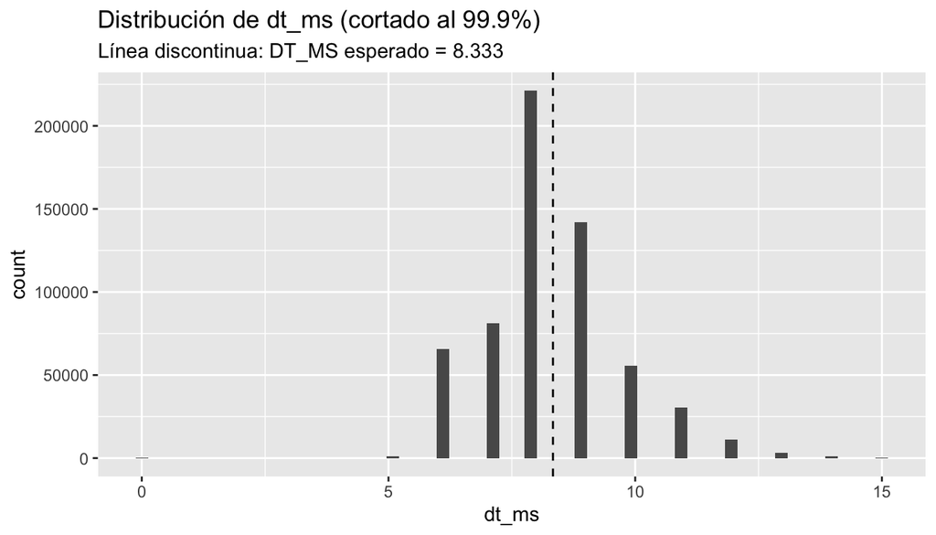

```r
ETdata_clean |>
  filter(dt_ms >= 0, dt_ms <= quantile(dt_ms, 0.999, na.rm = TRUE)) |>
  ggplot(aes(dt_ms)) +
  geom_histogram(bins = 60) +
  geom_vline(xintercept = DT_MS, linetype = 2) +
  labs(title = "Distribución de dt_ms (cortado al 99.9%)",
       x = "dt_ms", y = "count",
       subtitle = glue("Línea discontinua: DT_MS esperado = {round(DT_MS,3)}"))
```

# 3 Anclas y beeps

```r
# Chequeos básicos de coherencia temporal de anclas
anchors_ok <- ETdata_clean |>
  group_by(uniqueID) |>
  summarize(
    min_t        = min(t_ms, na.rm = TRUE),
    max_t        = max(t_ms, na.rm = TRUE),
    t1           = suppressWarnings(first(targ1StartTime_ms)),
    tf           = suppressWarnings(first(trialFinishTime_ms)),
    bStart       = suppressWarnings(first(beepStartTime_ms)),
    bDetect      = suppressWarnings(first(beepDetectTime_ms)),
    n_beepdetect = suppressWarnings(first(beepDetectionTrial))
  ) |>
  mutate(
    t1_in_range      = is.na(t1)      | (t1 >= min_t & t1 <= max_t),
    tf_in_range      = is.na(tf)      | (tf >= min_t & tf <= max_t),
    bStart_in_range  = is.na(bStart)  | (bStart >= min_t & bStart <= max_t),
    bDetect_in_range = is.na(bDetect) | (bDetect >= min_t & bDetect <= max_t),
    detect_consistent = ifelse(is.na(bDetect), n_beepdetect == 0, n_beepdetect == 1)
  )

summ_anchors <- anchors_ok |>
  summarize(
    pct_t1_in_range      = mean(t1_in_range) * 100,
    pct_tf_in_range      = mean(tf_in_range) * 100,
    pct_bStart_in_range  = mean(bStart_in_range) * 100,
    pct_bDetect_in_range = mean(bDetect_in_range) * 100,
    pct_detect_consistent= mean(detect_consistent) * 100
  )

summ_anchors |>
  mutate(across(everything(), ~ round(.x, 2))) |>
  kable(caption = "Coherencia de anclas y beeps (porcentaje OK)") |>
  kable_styling(full_width = FALSE)
```

Coherencia de anclas y beeps (porcentaje OK)

| pct_t1_in_range | pct_tf_in_range | pct_bStart_in_range | pct_bDetect_in_range | pct_detect_consistent |
| --- | --- | --- | --- | --- |
| 100 | 100 | 100 | 100 | 100 |

# 4 4. Proyección al plano: rangos y NA

```r
proj_stats <- ETdata_clean |>
  summarize(
    px_min = min(planeIntersect_x, na.rm = TRUE),
    px_max = max(planeIntersect_x, na.rm = TRUE),
    py_min = min(planeIntersect_y, na.rm = TRUE),
    py_max = max(planeIntersect_y, na.rm = TRUE),
    pct_NA_px = mean(is.na(planeIntersect_x)) * 100,
    pct_NA_py = mean(is.na(planeIntersect_y)) * 100,
    pct_out_of_bounds = mean(
      planeIntersect_x < -SHELF_BOUND | planeIntersect_x > SHELF_BOUND |
      planeIntersect_y < -SHELF_BOUND | planeIntersect_y > SHELF_BOUND,
      na.rm = TRUE
    ) * 100
  )

proj_stats |>
  mutate(across(where(is.numeric), ~ round(.x, 3))) |>
  kable(caption = "Rangos de proyección y %NA / out-of-bounds") |>
  kable_styling(full_width = FALSE)
```

Rangos de proyección y %NA / out-of-bounds

| px_min | px_max | py_min | py_max | pct_NA_px | pct_NA_py | pct_out_of_bounds |
| --- | --- | --- | --- | --- | --- | --- |
| -80.866 | 7.141 | -24.302 | 1.599 | 0.683 | 0.683 | 0.17 |

# 5 5. Invalid y invalidWindow (parpadeos + padding)

```r
inv_stats <- ETdata_clean |>
  summarize(
    pct_invalidData   = mean(invalidData == 1, na.rm = TRUE) * 100,
    pct_invalidWindow = mean(invalidWindow == 1, na.rm = TRUE) * 100
  )

inv_by_trial <- ETdata_clean |>
  group_by(uniqueID) |>
  summarize(prop_invalid = mean(invalidWindow == 1, na.rm = TRUE)) |>
  arrange(desc(prop_invalid)) |>
  mutate(rank = row_number())

inv_stats |>
  mutate(across(everything(), ~ round(.x, 2))) |>
  kable(caption = "Porcentaje global de muestras inválidas") |>
  kable_styling(full_width = FALSE)
```

Porcentaje global de muestras inválidas

| pct_invalidData | pct_invalidWindow |
| --- | --- |
| 0.85 | 3.41 |

```r
inv_by_trial |>
  slice_head(n = 12) |>
  kable(caption = "Top 12 trials por proporción de invalidWindow") |>
  kable_styling(full_width = FALSE)
```

Top 12 trials por proporción de invalidWindow

| uniqueID | prop_invalid | rank |
| --- | --- | --- |
| 9_5 | 0.2048371 | 1 |
| 3_12 | 0.0936515 | 2 |
| 26_9 | 0.0924282 | 3 |
| 26_10 | 0.0923567 | 4 |
| 12_0 | 0.0902740 | 5 |
| 23_17 | 0.0857070 | 6 |
| 9_13 | 0.0853301 | 7 |
| 23_15 | 0.0846175 | 8 |
| 11_1 | 0.0774236 | 9 |
| 3_3 | 0.0751860 | 10 |
| 29_17 | 0.0727798 | 11 |
| 7_19 | 0.0727418 | 12 |

# 6 6. Velocidades: distribución y outliers

```r
vel_stats <- ETdata_clean |>
  summarize(
    n_euc   = sum(!is.na(euc_vel)),
    q_euc   = list(quantile(euc_vel, probs = c(.5,.9,.99,.999), na.rm = TRUE)),
    n_ang   = sum(!is.na(ang_vel)),
    q_ang   = list(quantile(ang_vel, probs = c(.5,.9,.99,.999), na.rm = TRUE))
  )

vel_stats_tbl <- tibble(
  metric = c("euc_vel (m/s)","ang_vel (deg/s)"),
  q50 = c(vel_stats$q_euc[[1]][1], vel_stats$q_ang[[1]][1]),
  q90 = c(vel_stats$q_euc[[1]][2], vel_stats$q_ang[[1]][2]),
  q99 = c(vel_stats$q_euc[[1]][3], vel_stats$q_ang[[1]][3]),
  q999= c(vel_stats$q_euc[[1]][4], vel_stats$q_ang[[1]][4])
)

vel_stats_tbl |>
  mutate(across(-metric, ~ round(.x, 3))) |>
  kable(caption = "Cuantiles de velocidades") |>
  kable_styling(full_width = FALSE)
```

Cuantiles de velocidades

| metric | q50 | q90 | q99 | q999 |
| --- | --- | --- | --- | --- |
| euc_vel (m/s) | 0.430 | 6.523 | 25.712 | 41.463 |
| ang_vel (deg/s) | -444.588 | 17187.435 | 25268.729 | 29597.056 |

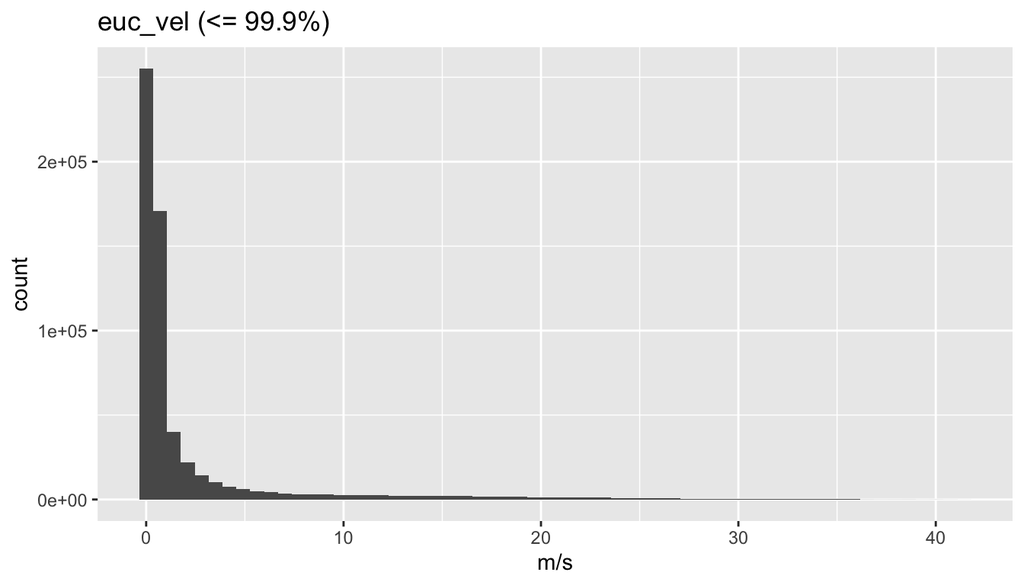

```r
p1 <- ETdata_clean |>
  filter(!is.na(euc_vel), euc_vel <= quantile(euc_vel, .999, na.rm = TRUE)) |>
  ggplot(aes(euc_vel)) + geom_histogram(bins = 60) +
  labs(title = "euc_vel (<= 99.9%)", x = "m/s", y = "count")

p2 <- ETdata_clean |>
  filter(!is.na(ang_vel), ang_vel <= quantile(ang_vel, .999, na.rm = TRUE)) |>
  ggplot(aes(ang_vel)) + geom_histogram(bins = 60) +
  labs(title = "ang_vel (<= 99.9%)", x = "deg/s", y = "count")

p1
```

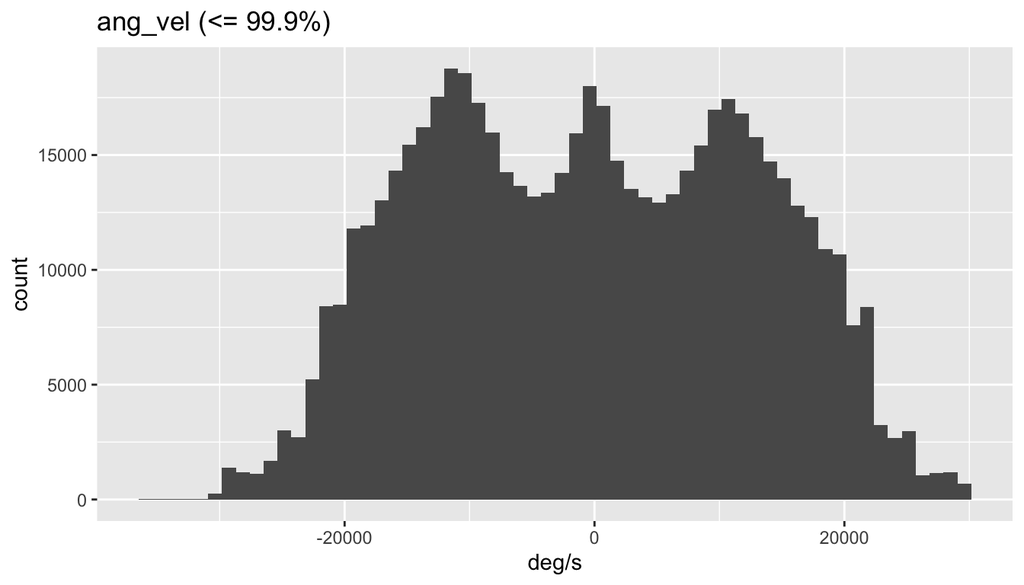

```r
p2
```

# 7. Interpolación a 120 Hz (regularidad del grid)

```r
grid_ok <- Interpdata |>
  group_by(uniqueID) |>
  summarize(
    n = n(),
    all_equal_dt = all(abs(dt_ms - DT_MS) < 1e-6),
    min_t = min(t_ms), max_t = max(t_ms),
    span_s = (max_t - min_t)/1000
  )

glue("Trials con dt_ms == DT_MS exacto: {sum(grid_ok$all_equal_dt)} / {nrow(grid_ok)}")
```

```
## Trials con dt_ms == DT_MS exacto: 181 / 181
```

```r
grid_ok |>
  arrange(desc(span_s)) |>
  slice_head(n = 10) |>
  mutate(across(c(min_t, max_t, span_s), ~ round(.x, 3))) |>
  kable(caption = "Top 10 trials por duración (Interpdata)") |>
  kable_styling(full_width = FALSE)
```

Top 10 trials por duración (Interpdata)

| uniqueID | n | all_equal_dt | min_t | max_t | span_s |
| --- | --- | --- | --- | --- | --- |
| 9_0 | 8915 | TRUE | 0 | 74283.33 | 74.283 |
| 9_5 | 8804 | TRUE | 0 | 73358.33 | 73.358 |
| 29_4 | 5927 | TRUE | 0 | 49383.33 | 49.383 |
| 29_6 | 5850 | TRUE | 0 | 48741.67 | 48.742 |
| 29_8 | 5819 | TRUE | 0 | 48483.33 | 48.483 |
| 9_13 | 5799 | TRUE | 0 | 48316.67 | 48.317 |
| 26_3 | 5206 | TRUE | 0 | 43375.00 | 43.375 |
| 7_8 | 5082 | TRUE | 0 | 42341.67 | 42.342 |
| 3_5 | 5050 | TRUE | 0 | 42075.00 | 42.075 |
| 7_9 | 5023 | TRUE | 0 | 41850.00 | 41.850 |

# 7 8. Consistencia de IDs entre ETdata_clean e Interpdata

```r
ids_et <- ETdata_clean |> distinct(uniqueID) |> arrange(uniqueID)
ids_ip <- Interpdata   |> distinct(uniqueID) |> arrange(uniqueID)

n_miss_et_in_ip <- sum(!(ids_et$uniqueID %in% ids_ip$uniqueID))
n_miss_ip_in_et <- sum(!(ids_ip$uniqueID %in% ids_et$uniqueID))

tibble(
  missing_ET_in_Interpdata = n_miss_et_in_ip,
  missing_Interpdata_in_ET = n_miss_ip_in_et
) |>
  kable() |>
  kable_styling(full_width = FALSE)
```

| missing_ET_in_Interpdata | missing_Interpdata_in_ET |
| --- | --- |
| 0 | 0 |

# 8 9. Plots diagnósticos rápidos

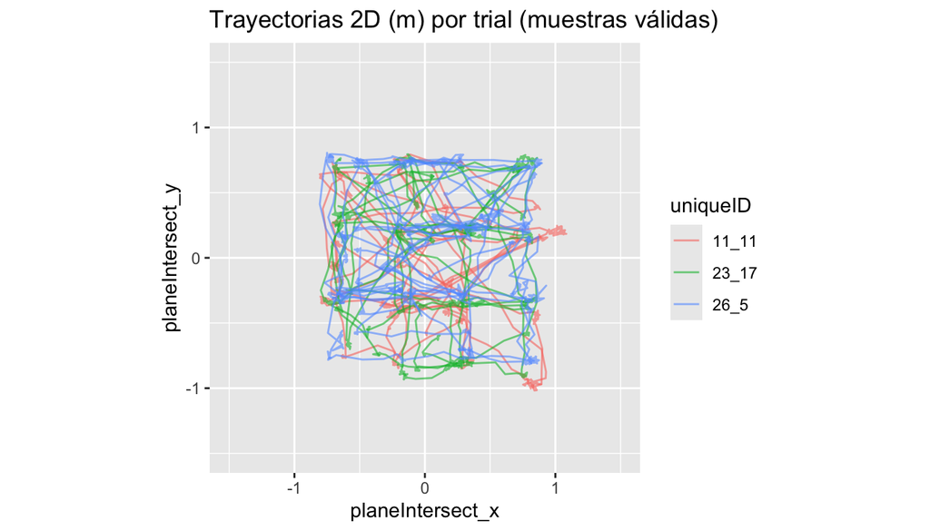

```r
# 3 trials aleatorios: trayectoria 2D en la balda
sample_ids <- sample(unique(ETdata_clean$uniqueID), size = min(3, length(unique(ETdata_clean$uniqueID))))
ETdata_clean |>
  filter(uniqueID %in% sample_ids, invalidWindow == 0) |>
  ggplot(aes(planeIntersect_x, planeIntersect_y, group = uniqueID, color = uniqueID)) +
  geom_path(alpha = 0.6) +
  coord_equal(xlim = c(-SHELF_BOUND, SHELF_BOUND), ylim = c(-SHELF_BOUND, SHELF_BOUND)) +
  labs(title = "Trayectorias 2D (m) por trial (muestras válidas)")
```

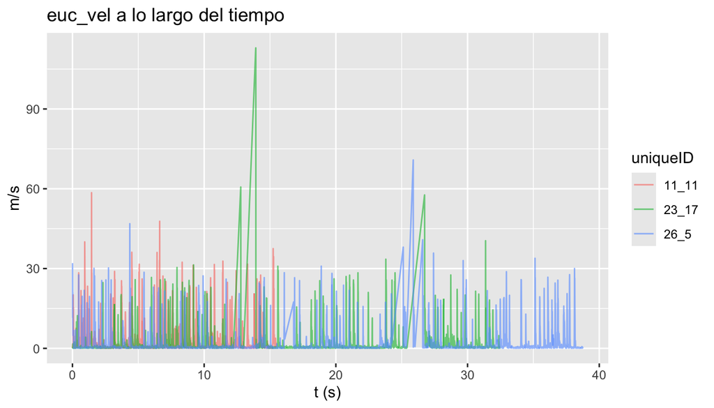

```r
# Serie temporal corta de euc_vel para esos trials
ETdata_clean |>
  filter(uniqueID %in% sample_ids, invalidWindow == 0) |>
  mutate(t_s = t_ms/1000) |>
  ggplot(aes(t_s, euc_vel, color = uniqueID)) +
  geom_line(alpha = 0.6) +
  labs(title = "euc_vel a lo largo del tiempo", x = "t (s)", y = "m/s")
```

# 10. Resumen de flags y guardado de reporte

```r
issues <- list(
  pct_non_monotone_trials   = mean(!mono_tbl$is_monotone) * 100,
  pct_t1_in_range           = mean(anchors_ok$t1_in_range) * 100,
  pct_tf_in_range           = mean(anchors_ok$tf_in_range) * 100,
  pct_bStart_in_range       = mean(anchors_ok$bStart_in_range) * 100,
  pct_bDetect_in_range      = mean(anchors_ok$bDetect_in_range) * 100,
  pct_detect_consistent     = mean(anchors_ok$detect_consistent) * 100,
  pct_invalidData_global    = mean(ETdata_clean$invalidData == 1, na.rm = TRUE) * 100,
  pct_invalidWindow_global  = mean(ETdata_clean$invalidWindow == 1, na.rm = TRUE) * 100,
  px_min = min(ETdata_clean$planeIntersect_x, na.rm = TRUE),
  px_max = max(ETdata_clean$planeIntersect_x, na.rm = TRUE),
  py_min = min(ETdata_clean$planeIntersect_y, na.rm = TRUE),
  py_max = max(ETdata_clean$planeIntersect_y, na.rm = TRUE),
  interp_all_equal_dt       = mean(grid_ok$all_equal_dt) * 100,
  ids_missing_et_in_ip      = sum(!(ids_et$uniqueID %in% ids_ip$uniqueID)),
  ids_missing_ip_in_et      = sum(!(ids_ip$uniqueID %in% ids_et$uniqueID))
)

issues_chr <- capture.output(str(issues))
writeLines(issues_chr, con = file.path(RESULTS_DIR, "sanity_summary.txt"))

cat("**Resumen escrito en** `results/sanity_summary.txt`")
```

```
## **Resumen escrito en** `results/sanity_summary.txt`
```

11. Notas de interpretación rápida • t_ms monotónico: debe ser monotónico dentro de cada uniqueID. Si aparece algún caso no monotónico, revisar glitches previos. • dt_ms ~ 8.33 ms: la mayoría de dt deberían concentrarse en ese valor; colas largas indican pérdidas o pausas. • Anclas/beeps: tiempos relativos deben caer dentro del rango de cada trial; beepDetectionTrial debe ser consistente con beepDetectTime_ms (NA vs. no NA). • Proyección: la mayoría de puntos dentro de ±SHELF_BOUND; NA altos o % fuera de rango suele indicar fallo de proyección o tracking. • Invalid/invalidWindow: el padding con PAD_BLINK_N hace crecer invalidWindow respecto a invalidData. Útil para filtrar parpadeos y oclusiones. • Velocidades: inspeccionar cuantiles altos (q99–q999) para detectar picos no fisiológicos (artefactos). • Interpolación: en Interpdata, dt_ms debe ser exactamente DT_MS en ~100% de trials. • Consistencia de IDs: ambos datasets deben tener el mismo conjunto de uniqueID.